# QBUS2820 - Predictive Analytics

# Tutorial 7 - Model Selection and Estimation

### Let's use the same appraoch as previous weeks to simulate some data

```python
import numpy as np
import matplotlib.pyplot as plt
from sklearn.metrics import mean_squared_error

# Initialise RNG, so we get same result everytime
np.random.seed(0)

# Number of training points
m = 50

x = np.linspace(0.0, 1.0, m)

# Function coefficients/parameters
beta0 = 4
beta1 = 1.5
beta2 =  3.2

# f values from 2nd order polynomial
f = beta0 + beta1 * x + beta2 * np.power(x,2)
```

$f$ contains data perfectly sampled along the 2nd order polynomial. In the real world we usually observe data that is noisy. So we will add a small amount of Gaussian noise to the data

```python
# Generate noisy sample from population
sigma2 = 0.1
y_train = f + np.random.normal(0, np.sqrt(sigma2), m)
y_validation = f + np.random.normal(0, np.sqrt(sigma2), m)
```

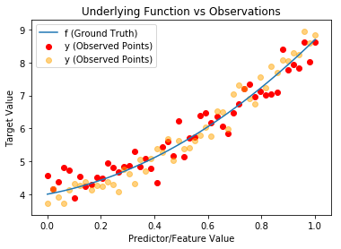

```python
fig1 = plt.figure()

plt.plot(x, f, label = "f (Ground Truth)")
plt.scatter(x, y_train, label = "y (Observed Points)", color = "red")
plt.scatter(x, y_validation, label = "y (Observed Points)", color = "orange", alpha = 0.5)

plt.xlabel("Predictor/Feature Value")
plt.ylabel("Target Value")
plt.title("Underlying Function vs Observations")
plt.legend(loc="upper left")

fig1
```

## Example: Using CV to Tune Hyperparameters

#### Let's try the GridSearchCV to find the optimal k

```python
# GridSearchCV
from sklearn.model_selection import GridSearchCV
from sklearn.neighbors import KNeighborsRegressor

# Set up the grid of parameters to search (in this case its 1 dimensional)
param_grid = {
    'n_neighbors': np.arange(1,11)
}

model = KNeighborsRegressor()

# Create the grid search object
grid_cv_obj = GridSearchCV(model, param_grid)

# Do the grid search
grid_cv_obj.fit(x.reshape(-1, 1), y_train)

print("Grid Search CV Complete!")
```

```
Grid Search CV Complete!
```

```python
# Get the best model
best_model = grid_cv_obj.best_estimator_

# Print the best model
print(best_model)
```

```
KNeighborsRegressor(algorithm='auto', leaf_size=30, metric='minkowski',
          metric_params=None, n_jobs=1, n_neighbors=4, p=2,
          weights='uniform')
```

```python
# Print the best params
print(grid_cv_obj.best_params_)
```

```
{'n_neighbors': 4}
```

```python
import pandas as pd

results = pd.DataFrame(grid_cv_obj.cv_results_)

results.head()
```

|  | mean_fit_time | mean_score_time | mean_test_score | mean_train_score | param_n_neighbors | params | rank_test_score | split0_test_score | split0_train_score | split1_test_score | split1_train_score | split2_test_score | split2_train_score | std_fit_time | std_score_time | std_test_score | std_train_score |
| --- | --- | --- | --- | --- | --- | --- | --- | --- | --- | --- | --- | --- | --- | --- | --- | --- | --- |
| 0 | 0.000000 | 0.001000 | -2.316441 | 1.000000 | 1 | {u'n_neighbors': 1} | 7 | -0.580521 | 1.000000 | 0.072439 | 1.000000 | -6.699040 | 1.000000 | 0.000000 | 1.123916e-07 | 3.018468 | 0.000000 |
| 1 | 0.000333 | 0.001000 | -2.256175 | 0.959266 | 2 | {u'n_neighbors': 2} | 6 | -1.266209 | 0.965728 | 0.107997 | 0.985972 | -5.819945 | 0.926099 | 0.000471 | 1.123916e-07 | 2.509526 | 0.024866 |
| 2 | 0.000333 | 0.000667 | -1.923537 | 0.918560 | 3 | {u'n_neighbors': 3} | 4 | -0.913748 | 0.930026 | -0.158417 | 0.973078 | -4.871876 | 0.852576 | 0.000471 | 4.713704e-04 | 2.046381 | 0.049858 |
| 3 | 0.000333 | 0.000667 | -1.684250 | 0.907321 | 4 | {u'n_neighbors': 4} | 1 | -0.279520 | 0.923605 | -0.222399 | 0.967415 | -4.729991 | 0.830944 | 0.000471 | 4.713704e-04 | 2.089494 | 0.056891 |
| 4 | 0.000333 | 0.000667 | -1.685084 | 0.906453 | 5 | {u'n_neighbors': 5} | 2 | -0.874074 | 0.922216 | -0.083843 | 0.965356 | -4.248101 | 0.831788 | 0.000471 | 4.713704e-04 | 1.788150 | 0.055656 |

#### Understanding Grid Search

In this example we only had one parameter so the grid is just a 1 dimensonal list.

**GridSearchCV** performs cross validation for each value of n_neighbours and returns the best value of n_neighbours.

We can use the **ParameterGrid** object in sklearn to list out all combinations of values that will be checked. In this case there are only 10.

```python
from sklearn.model_selection import ParameterGrid

grid_df = pd.DataFrame(list(ParameterGrid(param_grid)))

grid_df
```

|  | n_neighbors |
| --- | --- |
| 0 | 1 |
| 1 | 2 |
| 2 | 3 |
| 3 | 4 |
| 4 | 5 |
| 5 | 6 |
| 6 | 7 |
| 7 | 8 |
| 8 | 9 |
| 9 | 10 |

If we have 3 hyperparameters, then the number of parameter combinations that we have to search increases dramatically. We perform cross validation for each row in the parameter grid. Here we have shown the first 15 rows from 1000 ($10 \times 10 \times 10$) total rows.

```python
from sklearn.model_selection import ParameterGrid

param_grid = {
    'param_a': np.arange(1,11),
    'param_b': np.arange(101,111),
    'param_c': np.arange(-4,6),
}

grid_df_3 = pd.DataFrame(list(ParameterGrid(param_grid)))

grid_df_3.head(15)
```

|  | param_a | param_b | param_c |
| --- | --- | --- | --- |
| 0 | 1 | 101 | -4 |
| 1 | 1 | 101 | -3 |
| 2 | 1 | 101 | -2 |
| 3 | 1 | 101 | -1 |
| 4 | 1 | 101 | 0 |
| 5 | 1 | 101 | 1 |
| 6 | 1 | 101 | 2 |
| 7 | 1 | 101 | 3 |
| 8 | 1 | 101 | 4 |
| 9 | 1 | 101 | 5 |
| 10 | 1 | 102 | -4 |
| 11 | 1 | 102 | -3 |
| 12 | 1 | 102 | -2 |
| 13 | 1 | 102 | -1 |
| 14 | 1 | 102 | 0 |

Total number of combinations of hyperparamters

```python
len(grid_df_3)
```

```
1000
```

### Build the cross validation learning curve

CV for linear regression

```python
from sklearn.preprocessing import PolynomialFeatures
from sklearn.metrics import mean_squared_error
from sklearn.linear_model import LinearRegression
from sklearn.model_selection import cross_val_score

max_deg = 10

cv_scores_lr = []

for i in range(1, max_deg):

    poly_transformer = PolynomialFeatures(i)
    poly_x = poly_transformer.fit_transform(x.reshape(-1,1))

    # Create the linear regression object
    lin_reg = LinearRegression()

     # Uses 3-Fold by default
    # http://scikit-learn.org/stable/modules/generated/sklearn.metrics.make_scorer.html
    scores_lr = cross_val_score(lin_reg, poly_x, y_train, scoring = 'neg_mean_squared_error')

    # Get the mean of the scores from the 3 folds
    cv_score = np.mean(scores_lr)

    cv_scores_lr.append(cv_score)
```

```python
cv_scores_lr
```

```
[-0.76776824282588452,
 -0.2471889370479724,
 -1.6382231164261842,
 -11.62963133724679,
 -300.13865968973823,
 -2832.9134362128243,
 -10117.513235502312,
 -21932.132439798574,
 -3126766.5990956421]
```

The optimal Polynomial order

```python
1 + np.argmax(cv_scores_lr)
```

```
2
```

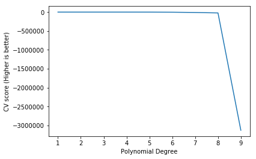

```python
fig = plt.figure()

plt.plot(np.arange(1,max_deg), cv_scores_lr)

plt.xlabel("Polynomial Degree")
plt.ylabel("CV score (Higher is better)")

fig
```

Note the in the above plot the extreme values, e.g. -3126766.599, make the pattern of the plot not clear. Let's only plot CV score versus the first 4 polynomial orders.

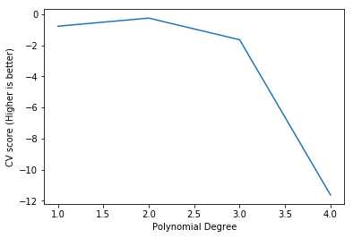

```python
fig = plt.figure()

plt.plot(np.arange(1,5), cv_scores_lr[0:4])

plt.xlabel("Polynomial Degree")
plt.ylabel("CV score (Higher is better)")

fig
```

## Example: Using CV to Evaluate Model Performance

Lets compare the performance of our best polynomial regression model with that of the knn regressor.

To ensure that each model sees the exact same K-Folds we need to store the K-Fold split in to a Python object and then share it to the cross_val_score function

```python
from sklearn.preprocessing import PolynomialFeatures
from sklearn.linear_model import LinearRegression

# Build poly2 model
poly_transformer = PolynomialFeatures(2)
poly_x = poly_transformer.fit_transform(np.reshape(x, (50,1)))
poly_reg = LinearRegression()
poly_reg.fit(poly_x, y_train)

# Build knn model
knn = KNeighborsRegressor(n_neighbors= 4)
knn.fit(x.reshape(-1,1), y_train)
```

```
KNeighborsRegressor(algorithm='auto', leaf_size=30, metric='minkowski',
          metric_params=None, n_jobs=1, n_neighbors=4, p=2,
          weights='uniform')
```

```python
from sklearn.model_selection import KFold

# 3-Fold Cross Validation
kf = KFold(3)

poly_scores = cross_val_score(poly_reg, poly_x, y_train, cv = kf)
poly_mean = np.mean(poly_scores)

knn_scores = cross_val_score(knn, x.reshape(-1,1), y_train, cv = kf)
knn_mean = np.mean(knn_scores)
```

```python
# Make the results pretty

data = [
    {"Model": "Polynomial Regression", "CV score": poly_mean},
    {"Model": "KNN Regressor", "CV score": knn_mean}
]

results = pd.DataFrame(data)
results = results.set_index("Model")
results
```

| Model | CV score |
| --- | --- |
| Polynomial Regression | -0.63556 |
| KNN Regressor | -1.74397 |

## Using AIC and BIC for model selection

```python
from sklearn.preprocessing import PolynomialFeatures
from sklearn.metrics import mean_squared_error
import statsmodels.api as sm # use statsmodels


max_deg = 10

aic_lr = []
bic_lr = []

for i in range(1, max_deg):

    poly_transformer = PolynomialFeatures(i)
    poly_x = poly_transformer.fit_transform(x.reshape(-1,1))

    # Create the linear regression object
    lin_reg = sm.OLS(y_train, poly_x).fit()

    # Get the mean of the scores from the 3 folds
    aic_value = lin_reg.aic
    bic_value = lin_reg.bic

    aic_lr.append(aic_value)
    bic_lr.append(bic_value)
```

See the below link for more detailed information on the statsmodels results https://www.statsmodels.org/dev/generated/statsmodels.regression.linear_model.RegressionResults.html

Linear regression summary with the highest Polynomial order

```python
print(lin_reg.summary())
```

```
                            OLS Regression Results
==============================================================================
Dep. Variable:                      y   R-squared:                       0.941
Model:                            OLS   Adj. R-squared:                  0.928
Method:                 Least Squares   F-statistic:                     70.73
Date:                Fri, 07 Sep 2018   Prob (F-statistic):           9.89e-22
Time:                        19:01:08   Log-Likelihood:                -14.253
No. Observations:                  50   AIC:                             48.51
Df Residuals:                      40   BIC:                             67.63
Df Model:                           9
Covariance Type:            nonrobust
==============================================================================
                 coef    std err          t      P>|t|      [0.025      0.975]
------------------------------------------------------------------------------
const          4.3961      0.335     13.106      0.000       3.718       5.074
x1            10.7406     21.377      0.502      0.618     -32.463      53.944
x2          -315.4226    432.667     -0.729      0.470   -1189.875     559.030
x3          3301.4835   3864.845      0.854      0.398   -4509.659    1.11e+04
x4         -1.672e+04   1.83e+04     -0.912      0.367   -5.38e+04    2.04e+04
x5          4.735e+04   5.05e+04      0.937      0.354   -5.47e+04    1.49e+05
x6         -7.865e+04   8.33e+04     -0.944      0.351   -2.47e+05    8.97e+04
x7          7.612e+04   8.11e+04      0.939      0.353   -8.78e+04     2.4e+05
x8         -3.974e+04   4.29e+04     -0.926      0.360   -1.26e+05     4.7e+04
x9          8648.2465   9523.291      0.908      0.369   -1.06e+04    2.79e+04
==============================================================================
Omnibus:                        0.062   Durbin-Watson:                   2.200
Prob(Omnibus):                  0.969   Jarque-Bera (JB):                0.085
Skew:                           0.063   Prob(JB):                        0.958
Kurtosis:                       2.842   Cond. No.                     3.56e+06
==============================================================================

Warnings:
[1] Standard Errors assume that the covariance matrix of the errors is correctly specified.
[2] The smallest eigenvalue is 7.09e-12. This might indicate that there are
strong multicollinearity problems or that the design matrix is singular.
```

The optimal Polynomial order with AIC. Note we want the min AIC:

```python
1 + np.argmin(aic_lr)
```

```
2
```

Visualise the AIC

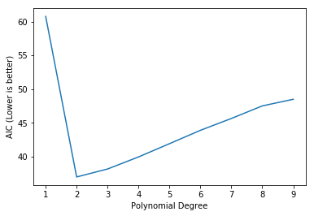

```python
fig = plt.figure()
plt.plot(np.arange(1,max_deg), aic_lr)
plt.xlabel("Polynomial Degree")
plt.ylabel("AIC (Lower is better)")
fig
```

The optimal Polynomial order with BIC. Note we want the min BIC:

```python
1 + np.argmin(bic_lr)
```

```
2
```

Visualise the BIC

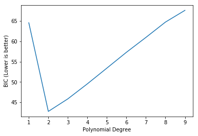

```python
fig = plt.figure()
plt.plot(np.arange(1,max_deg), bic_lr)
plt.xlabel("Polynomial Degree")
plt.ylabel("BIC (Lower is better)")
fig
```

## Manual K-Fold Cross Validation

In this section, Let's demonstrate what is happening when we use the cross_val_score function

```python
# Manual K-Folds
from sklearn.neighbors import KNeighborsRegressor
from sklearn.model_selection import cross_val_score

cv_scores = []

k_values = np.arange(1,11)

for k in k_values:
    knn = KNeighborsRegressor(n_neighbors = k)

    kf = KFold(3)

    scores = []

    for train_indices, valid_indices in kf.split(x):
        x_cvtrain = x[train_indices]
        x_cvvalid = x[valid_indices]

        y_cvtrain = y_train[train_indices]
        y_cvvalid = y_train[valid_indices]

        knn.fit(x_cvtrain.reshape(-1,1), y_cvtrain)

        y_cvpred = knn.predict(x_cvvalid.reshape(-1,1))

        error = -(mean_squared_error(y_cvvalid, y_cvpred))

        scores.append(error)

    # Get the mean of the scores from the 3 folds
    cv_score = np.mean(scores)

    cv_scores.append(cv_score)

print("Best value of k: {0}".format(k_values[np.argmax(cv_scores)]))
```

```
Best value of k: 5
```